# Hjemmeoppgaver - R-program sesjon 2

Jan Petter Iversen og Markus Mortensen

18 10 2019

# 1 Instruksjoner

Denne uken skal dere:

- opprette et repo på GitHub-profilen deres, clone det til RStudio, og løse oppgavene derfra
- løse oppgavene enten i en R Markdown-fil eller i et vanlig script (merk tydelig hvilken oppgave dere svarer på)
- committe og pushe til GitHub etterhvt som dere løser oppgaver

Når oppgaven er løst kan dere legge til jpiversen og markusmortensen som *collaborators* på repoet.

Vi har forsøkt å legge opp oppgavene etter stigende vanskelighetsgrad, men dersom man står fast på en oppgave kan man forsøke å gå videre og heller komme tilbake til denne oppgaven. Ingen oppgaver bygger direkte på hverandre, så dette skal være mulig å hoppe frem og tilbake.

Det vil være mange måter å løse disse oppgavene riktig på. Dersom oppgaven ber om at en funksjon må ha gitte input bør dette være med i funksjonen, men det er selvsagt mulig å gjøre funksjonene enda mer fleksible ved å legge til flere input eller annen funksjonalitet. Vær kreativ.

Forsøk å overholde programmeringsprinsippene og *best practice* fra slidene!

Frist for å løse oppgavene er fredag 25. oktober - før R-kurset neste uke.

# 2 Enkle funksjoner

**Eksempel** Noen av de neste oppgavene vil være på formen:

Lag en funksjon som tar ett valgfritt tall som input og returnerer tallet minus 3. Test på følgende vektor.

```r
x <- c(10, 20, 30)
```

Løsningsforslag:

```r
trekk_fra_tre <- function(x) {
  x - 3
}

trekk_fra_tre(x)
```

```
## [1]  7 17 27
```

De neste funksjonene kan testes på følgende vektorer:

```r
x <- c(1, 2, 3, 10)
y <- c(4, 5, 6, 23)
```

## 2.1 Summer to tall

Lag en funksjon som summerer to valgfrie tall

Svaret med x og y vektoren skal bli

```
## [1]  5  7  9 33
```

## 2.2 Multipliser to tall

Lag en funksjon som multipliserer to valgfrie tall

Svaret med x og y vektoren skal bli:

```
## [1]   4  10  18 230
```

## 2.3 Feilmelding

Se på følgende funksjon:

```r
kvadrer_x <- function(x) {
  x^2
}
```

Hvilken feilmelding vil vi få dersom vi kjører `kvadrer_x()`? Hvorfor?

Hvordan kan vi fikse dette?

## 2.4 Default value

Les help-filen til `cor()` (`?cor`, eller marker funksjonen og trykk F1). Hva betyr det at *default* verdien for *method* er `c("pearson", "kendall", "spearman")`? Hvilken verdi blir egentlig brukt som *default*?

## 2.5 Finnes 2 i vektoren?

Lag en funksjon som returnerer TRUE dersom tallet 2 finnes i vektoren.

Svaret med x-vektoren vil bli:

```
## [1] TRUE
```

Svaret med y-vektoren vil bli:

```
## [1] FALSE
```

## 2.6 Dårlig idé

Hvorfor er det en dårlig idé å gi funksjonen sin en av følgende navn:

- `mean()`
- `sum()`
- `mtcars()`

## 2.7 Partall

Lag en funksjonen `er_partall()` som tar en integer som input og returnerer `TRUE` dersom tallet er et partall.

Bonus: Hvorfor trenger man ikke lage funksjonen `er_oddetall()` hvis man alt har laget `er_partall()`?

## 2.8 IF ELSE IFELSE

Hva er forskjellen på `if()` og `ifelse()`? Hvilken ville du brukt når i en funksjon?

## 2.9 Funksjonen virker ikke

Denne funksjonen kommer ikke til å virke. Hvorfor?

```r
lag_histogram <-  function(.data, variabel) {

  .data %>%
    ggplot(aes(x = variabel)) +
    geom_histogram()

}
```

Bonus: Hvordan kan vi få den til å virke?

# 3 God

Skriv en funksjon som returner “God morgen”, “God formiddag”, “God ettermiddag” eller “God kveld” avhengig av hvilket tidspunkt man sender som input.

**Tips:** Bruk `lubridate::now()` som *default*, da blir det lettere å teste funksjonen.

# 4 Konverteringer 1

Formelen for å konvertere fahrenheit til celsius er:
$$Celsius = (Fahrenheit - 32) * \frac{5}{9}$$

Husk at det ikke er vanlig å snakke om grader i desimaltall…

```r
fahrenheit_to_celsius(32)
```

```
## [1] 0
```

```r
fahrenheit_to_celsius(64) # temperaturen i New York akkurat nå
```

```
## [1] 18
```

```r
celsius_to_fahrenheit(0) # vann fryser
```

```
## [1] 32
```

```r
celsius_to_fahrenheit(100) # vann koker
```

```
## [1] 212
```

```r
# Bonus:
fahrenheit_to_celsius(celsius_to_fahrenheit(23))
```

```
## [1] 23
```

# 5 DingDong

Lag funksjonen `dingdong()` som tar en vektor som input, og hvor output har følgende spesifikasjoner:

- Dersom $x_i$ er delelig med 3, returner “Ding”
- Dersom $x_i$ er delelig med 5, returner “Dong”
- Dersom $x_i$ er delelig med både 3 og 5, returner “DingDong”
- Ellers, returner tallet.

**Tips:** Gjør input om til en data.frame og benytt case_when for å løse denne oppgaven vektorisert

```r
dingdong(c(1:100))
```

```
##   [1] "1"        "2"        "Ding"     "4"        "Dong"     "Ding"
##   [7] "7"        "8"        "Ding"     "Dong"     "11"       "Ding"
##  [13] "13"       "14"       "DingDong" "16"       "17"       "Ding"
##  [19] "19"       "Dong"     "Ding"     "22"       "23"       "Ding"
##  [25] "Dong"     "26"       "Ding"     "28"       "29"       "DingDong"
##  [31] "31"       "32"       "Ding"     "34"       "Dong"     "Ding"
##  [37] "37"       "38"       "Ding"     "Dong"     "41"       "Ding"
##  [43] "43"       "44"       "DingDong" "46"       "47"       "Ding"
##  [49] "49"       "Dong"     "Ding"     "52"       "53"       "Ding"
##  [55] "Dong"     "56"       "Ding"     "58"       "59"       "DingDong"
##  [61] "61"       "62"       "Ding"     "64"       "Dong"     "Ding"
##  [67] "67"       "68"       "Ding"     "Dong"     "71"       "Ding"
##  [73] "73"       "74"       "DingDong" "76"       "77"       "Ding"
##  [79] "79"       "Dong"     "Ding"     "82"       "83"       "Ding"
##  [85] "Dong"     "86"       "Ding"     "88"       "89"       "DingDong"
##  [91] "91"       "92"       "Ding"     "94"       "Dong"     "Ding"
##  [97] "97"       "98"       "Ding"     "Dong"
```

# 6 print_all

En egenskap ved `tibble()` som ofte er nyttig er at den som *default* kun printer de 10 øverste radene av en dataframe. For store datasett er dette veldig greit, men for mindre datasett ønsker vi ofte å se alle radene.

For eksempel ville det vært greit å printe alle radene i dette tilfellet `iris %>% as_tibble() %>% head(25)`. Dette kan endres på ved å legge på en `print()` i *pipelinen* hvor man setter `n`-argumentet i `print` til en verdi som er minst like høy som det man ønsker å printe.

Lag en funksjon som heter `print_all()` som er en *wrapper* rundt `print()`, hvor man alltid printer alle radene.

Test at funksjonen fungerer som følger:

```r
iris %>% as_tibble %>% head(25) %>%  print_all()
```

```
## # A tibble: 25 x 5
##    Sepal.Length Sepal.Width Petal.Length Petal.Width Species
##           <dbl>       <dbl>        <dbl>       <dbl> <fct>
##  1          5.1         3.5          1.4         0.2 setosa
##  2          4.9         3            1.4         0.2 setosa
##  3          4.7         3.2          1.3         0.2 setosa
##  4          4.6         3.1          1.5         0.2 setosa
##  5          5           3.6          1.4         0.2 setosa
##  6          5.4         3.9          1.7         0.4 setosa
##  7          4.6         3.4          1.4         0.3 setosa
##  8          5           3.4          1.5         0.2 setosa
##  9          4.4         2.9          1.4         0.2 setosa
## 10          4.9         3.1          1.5         0.1 setosa
## 11          5.4         3.7          1.5         0.2 setosa
## 12          4.8         3.4          1.6         0.2 setosa
## 13          4.8         3            1.4         0.1 setosa
## 14          4.3         3            1.1         0.1 setosa
## 15          5.8         4            1.2         0.2 setosa
## 16          5.7         4.4          1.5         0.4 setosa
## 17          5.4         3.9          1.3         0.4 setosa
## 18          5.1         3.5          1.4         0.3 setosa
## 19          5.7         3.8          1.7         0.3 setosa
## 20          5.1         3.8          1.5         0.3 setosa
## 21          5.4         3.4          1.7         0.2 setosa
## 22          5.1         3.7          1.5         0.4 setosa
## 23          4.6         3.6          1           0.2 setosa
## 24          5.1         3.3          1.7         0.5 setosa
## 25          4.8         3.4          1.9         0.2 setosa
```

**PS:** En *wrapper* er en funksjon rundt en annen funksjon, hvor enten:

- Syntax er forenklet (mer intuitive navn, enklere/færre valg)
- Enkelte valg alt er satt

For eksemepel, hvis jeg aldri bruker `mean()`, men alltid `mean(na.rm = TRUE)` så kunne jeg laget en wrapper `mean_na()` som er en wrapper rundt `mean(x, na.rm = TRUE)`.

# 7 Passordgenerator

Å finne på nye passord blir bare vanskeligere og vanskeligere. Lag en funksjon som generer en tilfeldig string av valgfri lengde, som kun kan inneholde:

- Store bokstaver (kun engelske)
- Små bokstaver (kun engelske)
- Tall fra 0-9

**Tips:** R inneholder allerede vektoren `letters` som innholder hele det engelske alfabetet.

Eksempel output, med lengde lik 16:

```
## [1] "cOryq9ZVsOJqmbcN"
```

# 8 NA-funksjoner

Å lokalisere NA-verdier er et viktig sted i en *exploratory data analysis* og i validering av data inn til modeller.

1. Lag funksjonene `antall_na()` og `prosent_na()` som henholdsvis returnerer antallet og prosenten med missing values i en vektor.
2. Bruk en av map-funksjonene i purrr til å sjekke alle variablene i et valgfritt datasett for NA-verdier.

**Tips:** Datasettet airquality (som alt ligger i R) inneholder noen NA-verdier.

# 9 Innlastning av mange datafiler

HR lurer på i hvilket fylke de kan finne de smarteste nye PwCerne, slik at de kan sette inn støtet på rekruttering der.

Du får tilsendt en folder med 21 CSV-filer, som viser gjennomsnittkaraktene for de ulike fylkene mellom 2009 og 2016. Dataene ligger i en mappen “Karakterer_per_fylke” på Drive her: https://drive.google.com/drive/u/0/folders/1bJ2V2PiciOR4zm2mayRo5qh4Zf2eztEb.

Legg hele mappen med datafilene inn i prosjektmappen din, og bruk følgende kode for å lage en vektor med alle file pathene:

```r
file_paths <- fs::dir_ls(path = "./Karakterer_per_fylke", regexp = "\\.csv$")
```

Bruk en av map-funksjonene i `purrr` sammen med en av funksjonene i `readr` til å lese alle csv-filene og slå dem sammen til en data.frame.

Før du kan svare på HR sitt spørsmål må du rydde dataene litt.

Lag en ny data.frame, hvor:

- NA-verdier er blitt fjernet
- Du har brukt `tidyr::separate()` til å skille `variabel` til `variabel` og `year`.
- Du har filtrert vekk alle radene som ikke viser “Gjennomsnittlig standpunktkarakter”.

Når dette er gjort er du klar til å ta fatt på HR sitt spørsmål. Du bestemmer deg for å lage en funksjon som (minst) tar year som input, og returnerer de ti fylkene med høyest snittkarakter det året.

**Tips:** Husk det vi lærte om tidy eval.

Et eksempel på output er:

```r
transformert_df %>%
  finn_beste_fylke(year = 2016)
```

```
## # A tibble: 10 x 2
##    fylke               Gjennomsnittlig_karakter
##    <chr>                                  <dbl>
##  1 03 Oslo                                 4.08
##  2 14 Sogn og Fjordane                     4.08
##  3 02 Akershus                             4.05
##  4 07 Vestfold                             4.05
##  5 19 Troms - Romsa                        4.05
##  6 06 Buskerud                             4.04
##  7 12 Hordaland                            4.04
##  8 09 Aust-Agder                           4.03
##  9 18 Nordland                             4.03
## 10 04 Hedmark                              4.02
```

# 10 Fleksible plots

Lag en funksjon som genererer et relativt enkelt, men svært fleksibelt plot. Plottet skal kunne fungere på **alle** datasett med minst to numeriske kolonner.

**Tips:** Husk det vi lærte om tidy eval.

Vær kreativ, men et eksempel kan være:

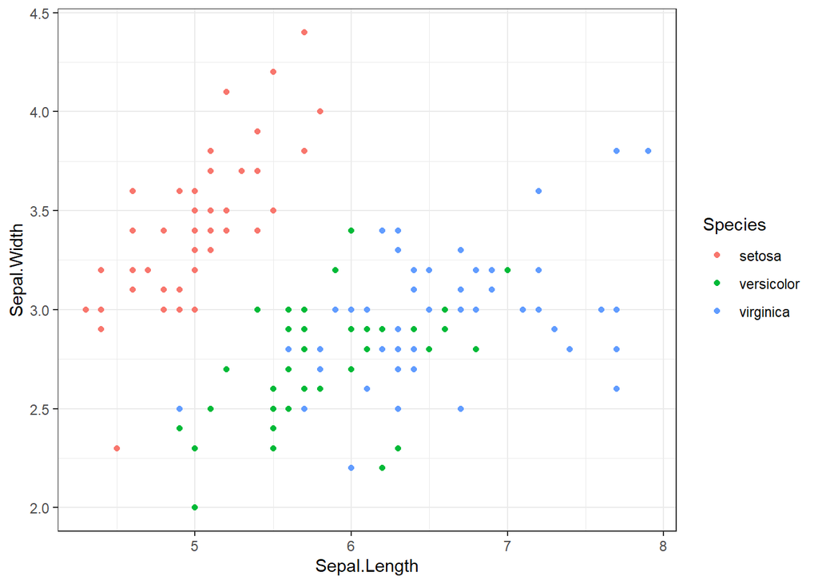

```r
# Dette plottet funker på alle datasett med to numeriske kolonner. Man kan selv spesifisere hvilke to kolonner som brukes i plottet, samt hvilken variabel man skal fargelegge etter. I tillegg er det enkelt å bytte tema da det ligger som et argument (med default).

iris %>%
  lag_plot(Sepal.Length, Sepal.Width, Species, theme_bw())
```

# 11 Konverteringer 2

1. *Miles per gallon* (mpg) gir ingen mening for oss i Norge. Lag en funksjon som tar mpg som input, og returnerer kilometer per liter (kpl).
2. Lag en funksjon som plotter valgfri variabel i mtcars opp mot `mpg`, men i plottet benyttes kpl istedenfor mpg.

**Tips:** Her er det ønskelig, men ikke nødvendig, at man benytter funksjon 1 inne i funksjon 2.

# 12 Rescale

Kjør følgende kode som laster ned aksjeprisene til Google, Apple og Facebook og plotter dem.

```r
if (!require(quantmod)) {
  install.packages("quantmod")
}

if (!require(reshape)) {
  install.packages("reshape")
}

# Last ned aksjedata
quantmod::getSymbols(c("GOOGL", "AAPL", "FB"), from = "2019-01-01")
```

```
## [1] "GOOGL" "AAPL"  "FB"
```

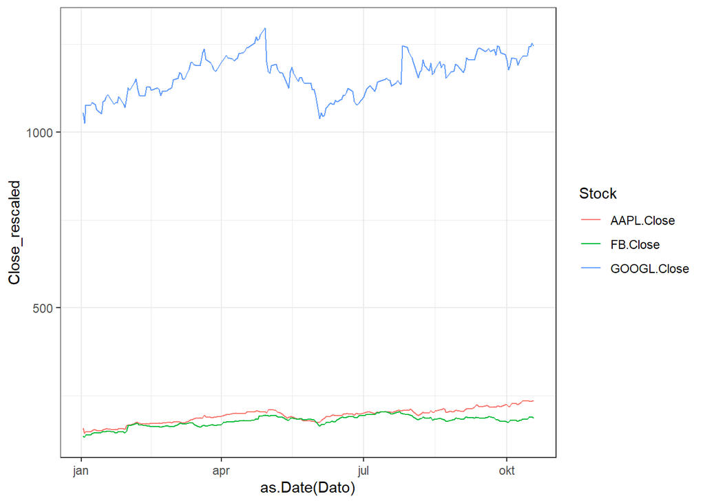

```r
# Lag liste av dataframes. Gjør radnavn til kolonne med navn "Dato"
list_of_df <- map(.x = list(FB = FB, GOOGL = GOOGL, AAPL = AAPL),
                  .f = ~(rownames_to_column(.data = as.data.frame(.),
                                            var = "Dato")))

# Join alle dfs på Dato
df_stocks <- reshape::merge_recurse(list_of_df)

# Plot
df_stocks %>%
  select(Dato, contains("Close")) %>%
  pivot_longer(-Dato, names_to = "Stock", values_to = "Close_rescaled") %>%
  ggplot(aes(x = as.Date(Dato), y = Close_rescaled, col = Stock, group = Stock)) +
  geom_line() +
  theme_bw()
```

Kjedelig at Google har så mye høyere aksjepris enn de to andre aksjene! Det gjør det svært vanskelig å sammenligne utviklingen til de tre aksjene.

Her trenger vi en funksjon som reskalerer aksjene til samme skala.

Lag en funksjon som tar en vektor som input og reskalerer til at første verdi er lik 100 og resterende verdier viser riktig prosentvis størrelse i forhold til start. Det vil si at for eksempel `c(10, 9, 15)` reskaleres til `c(100, 90, 150)`.

Dersom oppgaven er løst riktig skal man kunne benytte funksjonen i en mutate og få en graf som ser slik ut:

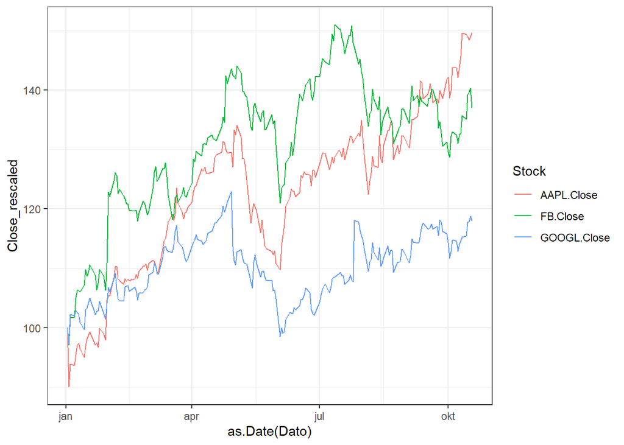

# 13 Navngivning

Les dokumentasjon og finn ut hva disse funksjonene gjør. Gi dem bedre navn.

```r
f1 <- function(string, prefix) {
  substr(string, 1, nchar(prefix)) == prefix
}

f2 <- function(x) {
  if (length(x) <= 1) return(NULL)
  x[-length(x)]
}

f3 <- function(x, y) {
  rep(y, length.out = length(x))
}

f4 <- function(x, y, z) {
  pmin(pmax(x, y), z)
}
```

# 14 Bli kvitt for-løkken

Bli kvitt for-løkkene i hvert av eksemplene under ved å bruke funksjoner som er vektorisert.

```r
out <- ""
for (x in letters) {
  out <- stringr::str_c(out, x)
}

x <- sample(100)
sd <- 0
for (i in seq_along(x)) {
  sd <- sd + (x[i] - mean(x)) ^ 2
}
sd <- sqrt(sd / (length(x) - 1))

x <- runif(100)
out <- vector("numeric", length(x))
out[1] <- x[1]
for (i in 2:length(x)) {
  out[i] <- out[i - 1] + x[i]
}
```

# 15 Feilmeldinger

Gå tilbake til funksjoner du har laget tidligere blant disse hjemmeoppgavene og legg til **fornuftige** *input checks* og feilmeldinger. Bruk gjerne pakkene `asertthat` og `checkmate`.

# 16 Lag en eksisterende funksjon

Implementer which.max() funksjonen selv. Alle funksjoner bortsett fra funksjonen selv (which.max()) kan brukes. Navngi funksjonen i tråd med tidyverse style guide.

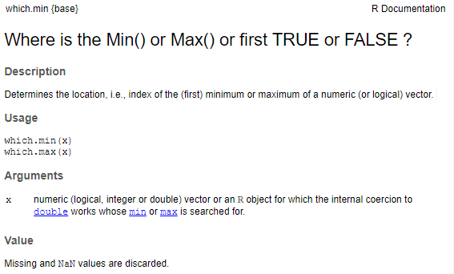

# 17 purrr

[figure not shown]

## 17.1 mtcars snitt av kolonner

Last inn mtcars og finn gjennomsnitt av hver kolonne. Bruk funksjoner fra purrr.

## 17.2 mtcars snitt av kolonner med trimming

Samme som over, men trim de 10% største og minste verdiene

## 17.3 type data i nycflights13::flights.

Bruk purrr til å finne hvilke type data som er i hver kolonne av nycflights13::flights.

## 17.4 Unike verdier Iris

Bruk purrr til å finne antall unike verdier i hver kolonne av iris-datasettet.

## 17.5 Erstatt for-loopen

```r
list <- c()
# Create a for statement to populate the list
for (i in seq(1, 4, by = 1)) {
  list[[i]] <- i*i
}

vector <- c()
for (i in seq(1, 10, by = 1)) {
  vector[[i]] <- i*i
}
```

Erstatt begge for-loopene over med funksjoner fra purrr-pakken

# 18 Programmere med dplyr

Skriv en funksjon som returnerer mean for alle numeriske kolonner i en data.frame.

Bonus: print resultatene på en fin måte.

# 19 Variable importance

`ranger` er en pakke i R for å lage *random forest*-modeller. Pakken har et par fordeler, for eksempel:

- den er svært rask
- den har gode default verdier
- defaultene, sammen med egenskapene til *random forest* gjør at den stort sett alltid kan brukes *rett out of the box*

Man kan for eksempel lage en modell for å klassifisere `Species` i iris-datasettet.

```r
if (!require(ranger)) {
  install.packages("ranger")
}

mod_ranger <- ranger(Species ~ .,
                     data = iris,
                     importance = "permutation")
```

Ved hjelp av funksjonen `ranger::importance()` kan man hente ut viktigheten av hver variabel i modellen.

Lag en funksjon som tar `mod_ranger` som input og laget et plot av viktigheten av variablene.

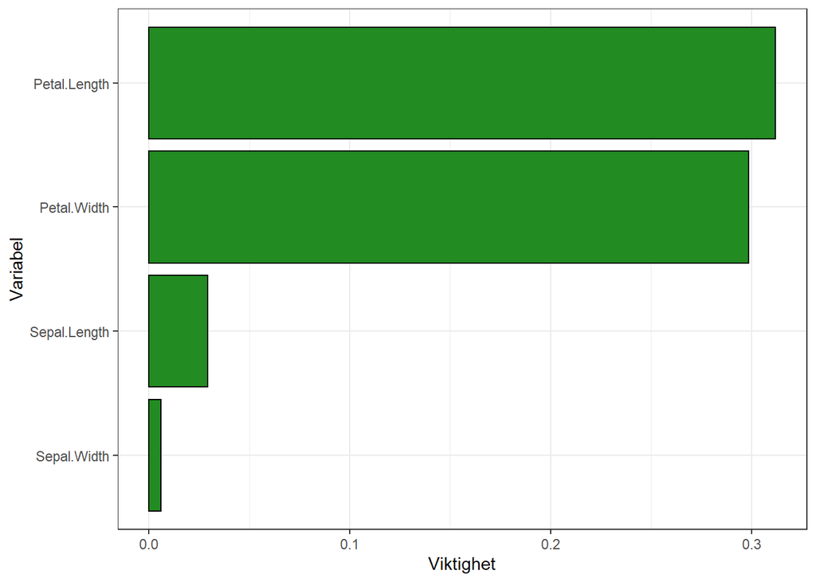

Bonus: Hvorfor er det nyttig å kunne sammenligne hvilke variabler modellen mener er viktig?

# 20 Dual lift

Dual lift plot er en visuell måte å sammenligne prediksjoner fra to modeller på. Denne statistikken er et mål på hvilken modell som treffer best i de områdene modellene skiller seg fra hverandre mest. Fremgangsmåte:

- Finn differansen mellom de to prediksjonene for hver observasjon
- Del inn i B kvantiler arrangert etter størrelsen på differansen
- Returner en data.frame med snitt av hver av prediksjonene og observerte verdier per kvantil.

Lag denne funksjonen.

Input er en data.frame med 3 kolonner: - truth - prediction1 - prediction2

La brukeren av funksjonen velge B, men sett en rimelig default-value.

Bonus: Kolonnenavnene kan være forskjellig fra det som står skrevet over.

```r
model_lm <- lm(mpg ~ ., data = mtcars)
model_rf <- ranger::ranger(mpg ~ ., data = mtcars)

df <- tibble(truth = mtcars$mpg,
             prediction1 = model_lm$fitted.values,
             prediction2 = model_rf$predictions)
```

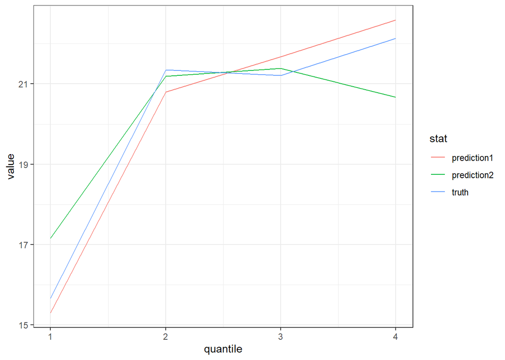

Bonus2: Gi en god forklaring til plottet. Når er en slik sammenligning nyttig?

Bonus3: Lag et bedre plot for å visualisere denne statistikken.

# 21 Bonusoppgave - frivillig

Lag en funksjon du mener er nyttig eller gøy, fortrinnsvis en som kunne vært brukt i prosjekt. Hvis mulig, legg ved noen eksempler på bruk av funksjonen, og forklar hvilket problem / hvilken oppgave den løser. Det blir premie til den som lager den beste funksjonen, basert på:

- nytteverdi
- kreativitet
- i hvor stor grad den følger programmeringsprinsippene fra kurset
- i hvor stor grad den følger best practice som finnes i slidene